# jumpman23_presentation

## Jumpman23 New York Market Analysis

```python
from IPython.display import HTML
HTML('''<script>
code_show=true;
function code_toggle() {
 if (code_show){
 $('div.input').hide();
 } else {
 $('div.input').show();
 }
 code_show = !code_show
}
$( document ).ready(code_toggle);
</script>
The code (Python 3) for this presentation is by default hidden for easier reading.
To toggle the code on/off, click <a href="javascript:code_toggle()">here</a>.''')
```

The code (Python 3) for this presentation is by default hidden for easier reading. To toggle the code on/off, click here.

```python
import pandas as pd
import numpy as np
import matplotlib.pyplot as plt
import matplotlib.image as mpimg
import pylab as plt2
from pylab import rcParams
import sys
import warnings
if not sys.warnoptions:
    warnings.simplefilter("ignore")
```

##### The following report outlines an analysis of the Jumpman23 project during October 2014, its first month in New York. The report covers the following sections:

1. Notes on data integrity
2. Summary statistics
3. Number of deliveries per week, day and hour
4. Deliveries by location
5. Delivery durations
6. Jumpmen analysis
7. Customer retention
8. Conclusion

### 1. Notes on data integrity

- The following features have missing values:
  - "how_long_it_took_to_order": 2945 of 5938 values are missing. Note: because of the many missing values, the time it took to order has not been considered in section 5: Delivery duration.
  - "when_the_Jumpman_arrived_at_pickup": 550 values are missing
  - "when_the_Jumpman_left_pickup": 550 values are missing
  - "place_category": 883 values are missing (replaced them with "Unknown")
  - "item_name", "item_quantity", "item_category_name": 1230 values are missing (replaced them with "Unknown")
- The feature "when_the_delivery_started" was not always recorded at the correct time. In 501 cases "when_the_delivery_started" was recorded later than "when_the_Jumpman_arrived_at_pickup". For the purpose of this report, the delivery time calculations of the affected cases have been ignored. However, it might be that "when_the_delivery_started" was recorded late in other cases as well. Therefore, this report might have underestimated the median delivery time.

### 2. Summary statistics

```python
# ---------- Load and prepare data ---------- #
data = pd.read_csv('analyze_me.csv')
# concatenate similar categories:
def revise_place_category(x):
    if x in ['Burger', 'American']:
        x = 'American/Burger'
    if x in ['Italian', 'Pizza']:
        x = 'Italian/Pizza'
    if x in ['Japanese', 'Sushi']:
        x = 'Japanese/Sushi'
    if x in ['Bakery', 'Dessert']:
        x = 'Bakery/Dessert'
    return x
# handle missing data:
data.place_category = data.place_category.fillna('Unknown')
data.item_name = data.item_name.fillna('Unknown')
data.item_category_name = data.item_category_name.fillna('Unknown')
data.item_quantity = data.item_quantity.fillna(1) # <- assume item quantity = 1 if unknown
# convert time data to datetime format:
data.place_category = data.place_category.apply(revise_place_category)
data.when_the_delivery_started = pd.to_datetime(data.when_the_delivery_started)
data.when_the_Jumpman_arrived_at_pickup = pd.to_datetime(data.when_the_Jumpman_arrived_at_pickup)
data.when_the_Jumpman_left_pickup = pd.to_datetime(data.when_the_Jumpman_left_pickup)
data.when_the_Jumpman_arrived_at_dropoff = pd.to_datetime(data.when_the_Jumpman_arrived_at_dropoff)
# add a column for the time it took to order in minutes:
data['how_long_it_took_to_order_min'] = data.how_long_it_took_to_order.\
    apply(lambda x: pd.Timestamp(x).minute + 1/60 * pd.Timestamp(x).second)
# add column with day of week (0: Monday, 6: Sunday)
data['weekday'] = data.when_the_delivery_started.apply(lambda x: x.weekday())
# add columns with amount of time it took for different tasks (and convert time to hours):
# (first remove "when_the_delivery_started" if time after "when_the_Jumpman_arrived_at_pickup")
data['time_JM_to_pickup'] = data.when_the_Jumpman_arrived_at_pickup - data.when_the_delivery_started
recorded_late_when_delivery_started = data['time_JM_to_pickup'].apply(lambda x: x.days) < 0
data['time_JM_to_pickup'][recorded_late_when_delivery_started] = pd.NaT
data['time_JM_to_pickup'] = data['time_JM_to_pickup'].apply(lambda x: pd.NaT if x.days < 0 else x)
data['time_JM_to_pickup'] = data['time_JM_to_pickup'].apply(lambda x: x.seconds/3600)
data['time_JM_wait'] = data.when_the_Jumpman_left_pickup - data.when_the_Jumpman_arrived_at_pickup
data['time_JM_wait'] = data['time_JM_wait'].apply(lambda x: x.seconds/3600)
data['time_JM_to_dropoff'] = data.when_the_Jumpman_arrived_at_dropoff - data.when_the_Jumpman_left_pickup
data['time_JM_to_dropoff'] = data['time_JM_to_dropoff'].apply(lambda x: x.seconds/3600)
data['time_delivery'] = data.when_the_Jumpman_arrived_at_dropoff - data.when_the_delivery_started
data['time_delivery'][recorded_late_when_delivery_started] = pd.NaT
data['time_delivery'] = data['time_delivery'].apply(lambda x: x.seconds/3600)
# create new data frame "data_ud" containing only unique delivery ids (info on items lost)
data_ud = data
deliver_ids_appeared = []
deliver_id_first_time = []
for id_ in data['delivery_id']:
    if id_ in deliver_ids_appeared:
        deliver_id_first_time.append(False)
    else:
        deliver_id_first_time.append(True)
        deliver_ids_appeared.append(id_)
data_ud['deliver_id_first_time'] = deliver_id_first_time
data_ud = data_ud[data_ud['deliver_id_first_time']]
```

```python
# ---------- Summary statistics ---------- #
n_deliveries = data_ud.shape[0]
first_date = data_ud.when_the_delivery_started.min()
last_date = data_ud.when_the_delivery_started.max()
n_days = last_date.day - first_date.day + 1
n_items = data.item_quantity.sum()
n_customers = data_ud.customer_id.unique().shape[0]
n_jumpmen = data_ud.jumpman_id.unique().shape[0]
avg_delivery_time = int(np.round(data_ud.time_delivery.mean() * 60))
avg_order_place_time = int(data['how_long_it_took_to_order_min'].mean())

print('Market data from ' + first_date.month_name() + ' ' + str(first_date.day) + ' to ' +\
      last_date.month_name() + ' ' + str(last_date.day) + ', ' + str(last_date.year) +
      ' (in total ' + str(n_days) + (' days') + str(')\n'))
print('Total number of deliveries: ' + str(n_deliveries) + ' (' + str(np.round(n_deliveries / n_days)) +
      ' per day)\n')
print('Total number of delivered items: ' + str(int(n_items)) + '\n')
print(str('Total number of customers: ') + str(n_customers) + '\n')
print(str('Total number of Jumpmen involved: ') + str(n_jumpmen) + '\n')
print('Average delivery time: ' + str(avg_delivery_time) + ' minutes\n')
print('Average time it took to place order: ' +str(avg_order_place_time) + ' minutes')
```

```
Market data from October 1 to October 30, 2014 (in total 30 days)

Total number of deliveries: 5214 (174.0 per day)

Total number of delivered items: 7163

Total number of customers: 3192

Total number of Jumpmen involved: 578

Average delivery time: 46 minutes

Average time it took to place order: 7 minutes
```

### 3. Number of deliveries per week, day, and hour

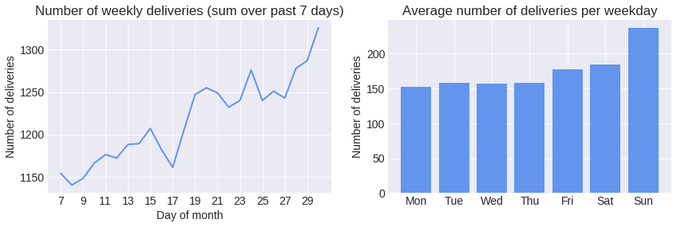

```python
# Activity over month
deliveries_per_day = data_ud.when_the_delivery_started.apply(lambda x: x.day).value_counts().sort_index()
deliveries_per_week = deliveries_per_day.rolling(7).sum()[6:]

# Activity per weekday:
deliveries_per_weekday = data_ud.weekday.value_counts().sort_index()
unique_days = data_ud.when_the_delivery_started.dropna().apply(lambda x: x.date()).unique()
from collections import defaultdict
d = defaultdict(int)
for day in unique_days:
    d[day.weekday()] += 1
deliveries_per_weekday = list(data_ud.when_the_delivery_started.apply(lambda x: x.weekday()).\
                              value_counts().sort_index())
# count number of deliveries for each weekday (some appear 4 times, others 5 times)
deliveries_per_weekday_norm = []
for i, deliveries in enumerate(deliveries_per_weekday):
    deliveries_per_weekday_norm.append(deliveries/d[i])

fig, [ax1, ax2] = plt.subplots(nrows=1, ncols=2)
plt.style.use('seaborn-darkgrid')
plt.rcParams.update({'figure.figsize': [14, 4], 'font.size': 14})
ax1.plot(deliveries_per_week, color='cornflowerblue', linewidth=2)
ax1.set_xticks(list(np.arange(7, 31, 2)))
ax1.set_xlabel('Day of month')
ax1.set_ylabel('Number of deliveries')
ax1.set_title('Number of weekly deliveries (sum over past 7 days)')
weekday_labels = ['Mon', 'Tue', 'Wed', 'Thu', 'Fri', 'Sat', 'Sun']
ax2.bar(weekday_labels, deliveries_per_weekday_norm, color='cornflowerblue')
ax2.set_ylabel('Number of deliveries')
ax2.set_title('Average number of deliveries per weekday')
plt.show()
```

- The total number of deliveries per week increased from around 1150 on October 7th to more than 1300 on October 30th
- On Sundays we have significantly more activity than during the week (~240 deliveries on an average Sunday vs ~160 deliveries on an average weekday)

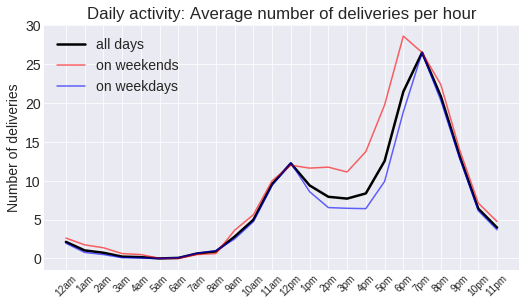

```python
# ---------- Activity over day ---------- #
n_weekend_days = d[5] + d[6]
n_week_days = n_days - n_weekend_days
deliveries_per_hour = data_ud.when_the_delivery_started.apply(lambda x: x.hour).value_counts()
deliveries_per_hour /= n_days

# take a separate look at weekdays vs weekends:
data_weekend = data_ud[(data_ud.weekday == 5) | (data_ud.weekday == 6)]
deliveries_per_hour_weekend = data_weekend.when_the_delivery_started.apply(lambda x: x.hour).value_counts()
deliveries_per_hour_weekend /= n_weekend_days
data_weekdays = data_ud[(data_ud.weekday != 5) & (data_ud.weekday != 6)]
deliveries_per_hour_weekdays = data_weekdays.when_the_delivery_started.apply(lambda x: x.hour).value_counts()
deliveries_per_hour_weekdays /= n_week_days

# Fill in 0's for the hours without any deliveries:
for i in range(24):
    if i not in deliveries_per_hour.index:
        deliveries_per_hour[i] = 0
    if i not in deliveries_per_hour_weekend.index:
        deliveries_per_hour_weekend[i] = 0
    if i not in deliveries_per_hour_weekdays.index:
        deliveries_per_hour_weekdays[i] = 0
deliveries_per_hour = deliveries_per_hour.sort_index()
deliveries_per_hour_weekend = deliveries_per_hour_weekend.sort_index()
deliveries_per_hour_weekdays = deliveries_per_hour_weekdays.sort_index()
am = [str(i) + 'am' for i in range(1, 13)]
pm = [str(i) + 'pm' for i in range(1, 13)]
hour_labels = [am[-1]] + am[:-1] + [pm[-1]] + pm[:-1]

x = list(deliveries_per_hour.index)
y_all = list(deliveries_per_hour.values)
y_weekend = list(deliveries_per_hour_weekend.values)
y_weekdays = list(deliveries_per_hour_weekdays.values)

plt2.rcParams.update({'figure.figsize': [8.5, 4.5], 'font.size': 14})
plt2.plot(y_all, alpha=1, c='black', linewidth=2.5)
plt2.plot(y_weekend, alpha=0.6, c='red')
plt2.plot(y_weekdays, alpha=0.6, c='blue')
plt2.xticks(x, hour_labels, rotation='45', fontsize=10)#, minor=True)
plt2.ylabel('Number of deliveries')
plt2.title('Daily activity: Average number of deliveries per hour')
plt.legend(['all days', 'on weekends', 'on weekdays'])
plt2.show()
```

- We see that the number of deliveries has a peak around lunchtime (Noon-1pm) on weekdays and another higher peak around dinner time (6pm to 8pm)
- On weekends there is no significant drop in orders after lunch time, the peak around dinner time remains

### 4. Deliveries by location

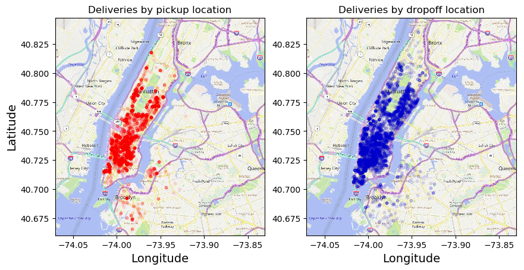

```python
nyc_map=mpimg.imread('nyc_map2.png')
x_left = -74.07065
x_right = -73.830665
y_bottom = 40.660223
y_top = 40.847736
fig, [ax1, ax2] = plt.subplots(nrows=1, ncols=2, figsize=(10, 8))
plt.rcParams.update({'font.size': 14})
plt.style.use('default')

# Plot pickup locations
ax1.scatter(x=data_ud["pickup_lon"], y=data_ud["pickup_lat"], c='red', s=10, alpha=0.1)
ax1.imshow(nyc_map, extent=[x_left, x_right, y_bottom, y_top], aspect=1.33)
ax1.set_ylabel("Latitude", fontsize=14)
ax1.set_xlabel("Longitude", fontsize=14)
ax1.set_title('Deliveries by pickup location')
# Plot dropoff locations
ax2.scatter(x=data_ud["dropoff_lon"], y=data_ud["dropoff_lat"], c='mediumblue', s=10, alpha=0.1)
ax2.imshow(nyc_map, extent=[x_left, x_right, y_bottom, y_top], aspect=1.33)
ax2.set_ylabel(" ")
ax2.set_xlabel("Longitude", fontsize=14)
ax2.set_title('Deliveries by dropoff location')
plt.show()
```

The majority of deliveries appears to be in Manhattan. Some are in Brooklyn and almost none in Queens, Bronx or Staten Island.

To see how our results differ by location, let's subdivide the data into the following three areas (by pickup location):

- Manhattan North
- Manhattan South
- Brooklyn

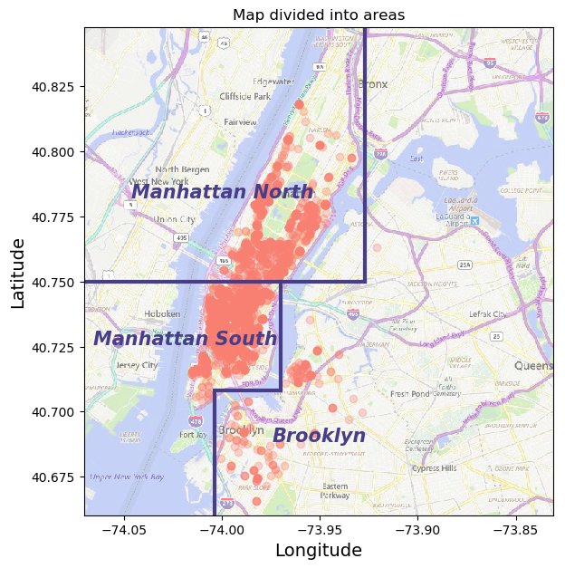

```python
# ---------- Divide map into different areas ---------- #
# Plot lines for area segmentation and annotation:
pntA = (-73.927, 40.75)
pntB = (-73.97, 40.75)
pntC = (-73.97, 40.708)
pntD = (-74.004, 40.708)
# Scatter plot with pickup locations:
plt.style.use('fast')
fig = plt.figure(figsize=(10, 7))
ax = fig.add_subplot(111)
ax.scatter(x=data_ud["pickup_lon"], y=data_ud["pickup_lat"], c='salmon', alpha=0.3)
c = 'darkslateblue'
ax.axvline(x=pntA[0], ymin=(pntA[1]-y_bottom)/(y_top-y_bottom), ymax=1, \
           linewidth=3, color=c)
ax.axhline(y=pntB[1], xmin=0, xmax=(pntA[0]-x_left)/(x_right-x_left), linewidth=3, color=c)
ax.axvline(x=pntC[0], ymin=(pntC[1]-y_bottom)/(y_top-y_bottom), ymax=(pntB[1]-y_bottom)/(y_top-y_bottom), \
           linewidth=3, color=c)
ax.axhline(y=pntC[1], xmin=(pntD[0]-x_left)/(x_right-x_left), xmax=(pntC[0]-x_left)/(x_right-x_left),\
           linewidth=3, color=c)
ax.axvline(x=pntD[0], ymin=0, ymax=(pntD[1]-y_bottom)/(y_top-y_bottom), linewidth=3, color=c)
ax.text(0.1, 0.65, 'Manhattan North', transform=ax.transAxes, fontsize=15, style='italic', weight='bold', color=c)
ax.text(0.02, 0.35, 'Manhattan South', transform=ax.transAxes, fontsize=15, style='italic', weight='bold', color=c)
ax.text(0.4, 0.15, 'Brooklyn', transform=ax.transAxes, fontsize=15, style='italic', weight='bold', color=c)
ax.set_ylabel("Latitude", fontsize=14)
ax.set_xlabel("Longitude", fontsize=14)
ax.set_title('Map divided into areas')
ax.imshow(nyc_map, extent=[x_left, x_right, y_bottom, y_top], alpha=0.7, aspect=1.33)
plt.show()
```

```python
# Add column in data set for area (Manhattan North, Manhattan South, Brooklyn)
pntA = (-73.927, 40.75)
pntB = (-73.97, 40.75)
pntC = (-73.97, 40.708)
pntD = (-74.004, 40.708)
pickup_lat = data_ud.pickup_lat
pickup_lon = data_ud.pickup_lon
pickup_area = []
for lat, lon in zip(pickup_lat, pickup_lon):
    if lat >= pntA[1]:
        if lon <= pntA[0]:
            pickup_area.append('Manhattan North')
        else:
            pickup_area.append('Brooklyn')
    elif lat >= pntC[1]:
        if lon <= pntC[0]:
            pickup_area.append('Manhattan South')
        else:
            pickup_area.append('Brooklyn')
    else:
        if lon <= pntD[0]:
            pickup_area.append('Manhattan South')
        else:
            pickup_area.append('Brooklyn')
data_ud['pickup_area'] = pickup_area
```

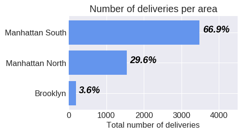

```python
# ---------- Barplot with number of deliveries by area ---------- #
pickup_area_counts = data_ud['pickup_area'].value_counts()[::-1]
plt.style.use('seaborn-darkgrid')
fig, ax = plt.subplots()
plt.rcParams.update({'figure.figsize': [4.5, 2.5], 'font.size': 12})
ax.barh(pickup_area_counts.index, pickup_area_counts.values, color='cornflowerblue')
ax.set_xlim([0, 4500])
ax.set_xlabel('Total number of deliveries')
ax.set_title('Number of deliveries per area')

# Create labels that indicate percentage:
labels = [np.round(cnt/pickup_area_counts.values.sum()*100, 1) for cnt in pickup_area_counts.values]
labels = [str(l) + '%' for l in labels]
rects = ax.patches
for rect, label in zip(rects, labels):
    x_value = rect.get_width()
    y_value = rect.get_y() + rect.get_height() / 2
    ax.text(x_value + 80, y_value, label, color='black', fontsize=14, style='italic', weight='bold')#,
plt.show()
```

As the maps indicated, most of the deliveries are coming from Manhattan. We can also see that in the South (downtown, area below Time Square) there are more than twice the amount of delivery pickups than in the North of Manhattan.

### 5. Delivery duration

Let's take a look at the delivery duration. The total delivery duration is the sum of the following 3 components:

- Time until Jumpan arrived ad Pickup
- Time Jumpman waited at Pickup
- Time Jumpan took to deliver to drop-off

Note: The time it took to place an order has not been taken into account in this analysis due to too many missing values. It took on average 7 minutes to place an order

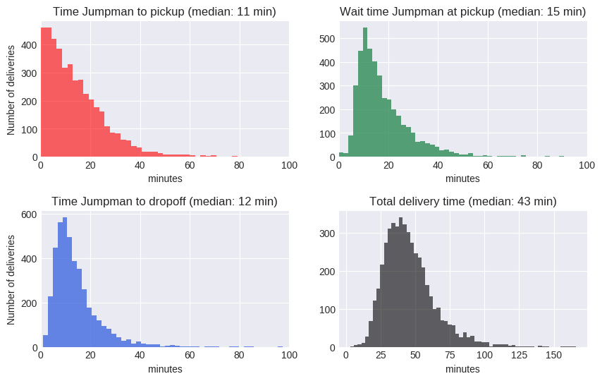

```python
# ---------- Plot delivery times and components ---------- #
# remove rows with delivery times > 3hrs (outliers, in total there are 5)
data_dt = data_ud[data_ud['time_delivery'] < 3]
JM_to_pickup_min = data_dt['time_JM_to_pickup'].dropna() * 60
JM_wait_min = data_dt['time_JM_wait'].dropna() * 60
JM_to_dropoff_min = data_dt['time_JM_to_dropoff'].dropna() * 60
delivery_total_min = data_dt['time_delivery'].dropna() * 60

# Plot histograms:
fig, [[ax1, ax2], [ax3, ax4]] = plt.subplots(nrows=2, ncols=2, figsize=(10, 6))#, constrained_layout=True)
plt.subplots_adjust(hspace=0.4)
plt.rcParams.update({'font.size': 10})

ax1 = plt.subplot(221)
ax1.hist(JM_to_pickup_min, bins=60, alpha=0.6, color='red')
ax1.set_xlim([0, 100])
ax1.set_xlabel('minutes')
ax1.set_ylabel('Number of deliveries')
ax1.set_title('Time Jumpman to pickup (median: %0.0f min)' % np.median(JM_to_pickup_min))

ax2 = plt.subplot(222)
ax2.hist(JM_wait_min, bins=60, alpha=0.8, color='seagreen')
ax2.set_xlim([0, 100])
ax2.set_xlabel('minutes')
ax2.set_title('Wait time Jumpman at pickup (median: %0.0f min)' % np.median(JM_wait_min))

ax3 = plt.subplot(223)
ax3.set_xlim([0, 100])
ax3.hist(JM_to_dropoff_min, bins=60, alpha=0.8, color='royalblue')
ax3.set_xlabel('minutes')
ax3.set_ylabel('Number of deliveries')
ax3.set_title('Time Jumpman to dropoff (median: %0.0f min)' % np.median(JM_to_dropoff_min))

ax4 = plt.subplot(224)
ax4.hist(delivery_total_min, bins=60, alpha=0.6, color='black')
ax4.set_xlabel('minutes')
ax4.set_title('Total delivery time (median: %0.0f min)' % np.median(delivery_total_min))
fig.show()
```

#### Delivery times by area

Let's see how the delivery times compare for Manhattan North, Manhattan South and Brooklyn

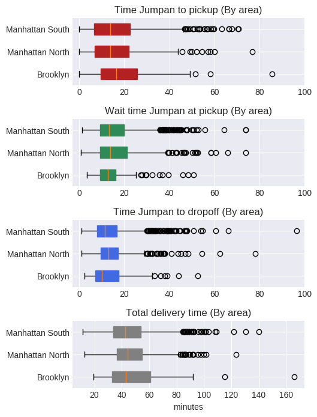

```python
# ---------- Customer retention by delivery speed ---------- #
fig, [ax1, ax2, ax3, ax4] = plt.subplots(nrows=4, ncols=1, figsize=(5, 8))
plt.rcParams.update({'font.size': 10})
plt.subplots_adjust(hspace=0.5)

ax1 = plt.subplot(411)
bp1 = ax1.boxplot([data_dt[data_dt.pickup_area=='Brooklyn'].dropna().time_JM_to_pickup * 60, \
            data_dt[data_dt.pickup_area=='Manhattan North'].dropna().time_JM_to_pickup * 60, \
            data_dt[data_dt.pickup_area=='Manhattan South'].dropna().time_JM_to_pickup * 60],\
           widths=(0.5, 0.5, 0.5), patch_artist=True, vert=False)
ax1.set_yticklabels(['Brooklyn', 'Manhattan North', 'Manhattan South'])
ax1.set_xlim([-3, 100])
ax1.set_title('Time Jumpan to pickup (By area)')

ax2 = plt.subplot(412)
bp2 = ax2.boxplot([data_dt[data_dt.pickup_area=='Brooklyn'].dropna().time_JM_wait * 60, \
            data_dt[data_dt.pickup_area=='Manhattan North'].dropna().time_JM_wait * 60, \
            data_dt[data_dt.pickup_area=='Manhattan South'].dropna().time_JM_wait * 60],\
           widths=(0.5, 0.5, 0.5), patch_artist=True, vert=False)
ax2.set_yticklabels(['Brooklyn', 'Manhattan North', 'Manhattan South'])
ax2.set_xlim([-3, 100])
ax2.set_title('Wait time Jumpan at pickup (By area)')

ax3 = plt.subplot(413)
bp3 = ax3.boxplot([data_dt[data_dt.pickup_area=='Brooklyn'].dropna().time_JM_to_dropoff * 60, \
            data_dt[data_dt.pickup_area=='Manhattan North'].dropna().time_JM_to_dropoff * 60, \
            data_dt[data_dt.pickup_area=='Manhattan South'].dropna().time_JM_to_dropoff * 60],\
           widths=(0.5, 0.5, 0.5), patch_artist=True, vert=False)
ax3.set_yticklabels(['Brooklyn', 'Manhattan North', 'Manhattan South'])
ax3.set_xlim([-3, 100])
ax3.set_title('Time Jumpan to dropoff (By area)')

ax4 = plt.subplot(414)
bp4 = ax4.boxplot([data_dt[data_dt.pickup_area=='Brooklyn'].dropna().time_delivery * 60, \
            data_dt[data_dt.pickup_area=='Manhattan North'].dropna().time_delivery * 60, \
            data_dt[data_dt.pickup_area=='Manhattan South'].dropna().time_delivery * 60],\
           widths=(0.5, 0.5, 0.5), patch_artist=True, vert=False)
ax4.set_yticklabels(['Brooklyn', 'Manhattan North', 'Manhattan South'])
ax4.set_xlabel('minutes')
ax4.set_title('Total delivery time (By area)')

for patch in bp1['boxes']:
    patch.set(color = 'firebrick')
for patch in bp2['boxes']:
    patch.set(color = 'seagreen')
for patch in bp3['boxes']:
    patch.set(color = 'royalblue')
for patch in bp4['boxes']:
    patch.set(color = 'gray')
plt.show()
```

The boxplots above show the distribution of the different delivery time components by area. We notice an interesting difference between Brooklyn and the two areas in Manhattan: While the wait time and time for the Jumpman to drop-off tend to be relatively short in Brooklyn, the time a Jumpan takes to get to the pickup location is often the longest in Brooklyn. This indicates that Brooklyn tends to be at limited capacity and could use more Jumpmen.

#### Delivery times by day time

Let's take a look how the median delivery time changes during an average day

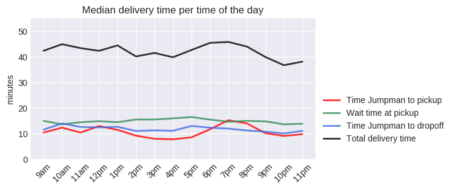

```python
# ---------- Plot delivery time by time of day ---------- #
time_JM_to_pickup_per_hour = []
JM_wait_per_hour = []
JM_to_dropoff_per_hour = []
delivery_total_per_hour = []
for h in np.arange(9, 24):
    time_JM_to_pickup_per_hour.append(np.median(data_dt[data_dt.when_the_delivery_started.\
            apply(lambda x: x.hour) == h]['time_JM_to_pickup'].dropna()) * 60)
    JM_wait_per_hour.append(np.median(data_dt[data_dt.when_the_delivery_started.\
            apply(lambda x: x.hour) == h]['time_JM_wait'].dropna()) * 60)
    JM_to_dropoff_per_hour.append(np.median(data_dt[data_dt.when_the_delivery_started.\
            apply(lambda x: x.hour) == h]['time_JM_to_dropoff'].dropna()) * 60)
    delivery_total_per_hour.append(np.median(data_dt[data_dt.when_the_delivery_started.\
            apply(lambda x: x.hour) == h]['time_delivery'].dropna()) * 60)
plt2.rcParams.update({'figure.figsize': [6, 3], 'font.size': 10})
plt2.plot(time_JM_to_pickup_per_hour, alpha=0.8, c='red', linewidth=2)
plt2.plot(JM_wait_per_hour, alpha=0.8, c='seagreen', linewidth=2)
plt2.plot(JM_to_dropoff_per_hour, alpha=0.8, c='royalblue', linewidth=2)
plt2.plot(delivery_total_per_hour, alpha=0.8, c='black', linewidth=2)
plt2.xticks(list(np.arange(0, 15)), hour_labels[9:], rotation='45', fontsize=10)
plt2.ylabel('minutes')
plt2.ylim([0, 55])
plt2.title('Median delivery time per time of the day')
plt.legend(['Time Jumpman to pickup', 'Wait time at pickup', 'Time Jumpman to dropoff', \
           'Total delivery time'], bbox_to_anchor=(1, 0.5))
plt2.show()
```

While the median waiting time and delivery time remain approximately constant during the day, we can see that the time a Jumpman needs to arrive at the pickup location peeks at the busiest time (around dinner time). This indicates that there might be the need for more Jumpmen around these hours.

#### Median delivery time change over one month period

Next, let's take a look at how the median delivery times changed between October 1 and October 30

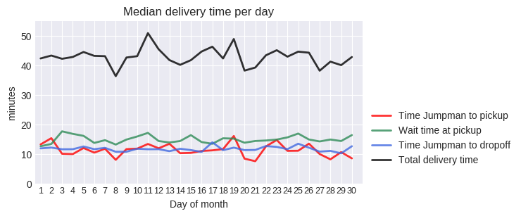

```python
# ---------- Plot delivery time by time of day ---------- #
day_labels = np.arange(1,31)
time_JM_to_pickup_per_day = []
JM_wait_per_day = []
JM_to_dropoff_per_day = []
delivery_total_per_day = []
for d in np.arange(1, 31):
    time_JM_to_pickup_per_day.append(np.median(data_dt[data_dt.when_the_delivery_started.\
            apply(lambda x: x.day) == d]['time_JM_to_pickup'].dropna()) * 60)
    JM_wait_per_day.append(np.median(data_dt[data_dt.when_the_delivery_started.\
            apply(lambda x: x.day) == d]['time_JM_wait'].dropna()) * 60)
    JM_to_dropoff_per_day.append(np.median(data_dt[data_dt.when_the_delivery_started.\
            apply(lambda x: x.day) == d]['time_JM_to_dropoff'].dropna()) * 60)
    delivery_total_per_day.append(np.median(data_dt[data_dt.when_the_delivery_started.\
            apply(lambda x: x.day) == d]['time_delivery'].dropna()) * 60)
plt2.rcParams.update({'figure.figsize': [6, 3], 'font.size': 10})
plt2.plot(time_JM_to_pickup_per_day, alpha=0.8, c='red', linewidth=2)
plt2.plot(JM_wait_per_day, alpha=0.8, c='seagreen', linewidth=2)
plt2.plot(JM_to_dropoff_per_day, alpha=0.8, c='royalblue', linewidth=2)
plt2.plot(delivery_total_per_day, alpha=0.8, c='black', linewidth=2)
plt2.xticks(list(np.arange(0, 30)), day_labels, fontsize=9)
plt2.xlabel('Day of month')
plt2.ylabel('minutes')
plt2.xlim([-0.5, 30])
plt2.ylim([0, 55])
plt2.title('Median delivery time per day')
plt.legend(['Time Jumpman to pickup', 'Wait time at pickup', 'Time Jumpman to dropoff', \
           'Total delivery time'], bbox_to_anchor=(1, 0.5))
plt2.show()
```

While there is a strong variance in the median delivery time per day over the one month period, there is no evidence that the delivery time is generally increasing and that Jumpmen could not keep up with the increasing demand.

### 6. Jumpen analysis

Let's take a look at overall Jumpmen activity.

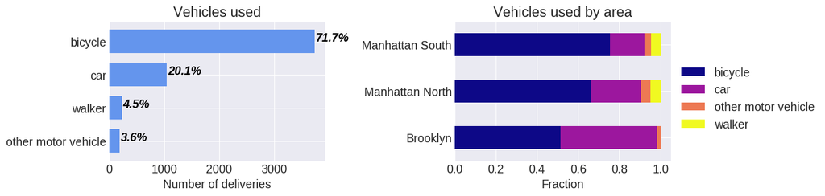

```python
# ---------- Analyze vehicle types ---------- #
data_ud['vehicle_type'][data_ud['vehicle_type'].apply(lambda x: (x == 'motorcycle') | (x == 'scooter') |\
                              (x == 'truck')| (x == 'van'))] = 'other motor vehicle'
vehicle_ct = pd.crosstab(data_ud['pickup_area'], data_ud['vehicle_type'], normalize='index')
vehicle_type = data_ud['vehicle_type'].value_counts()[::-1]

plt.style.use('seaborn-darkgrid')
fig, [ax1, ax2] = plt.subplots(nrows=1, ncols=2, figsize=(12, 3))#, constrained_layout=True)
plt.subplots_adjust(wspace=0.6)
plt.rcParams.update({'font.size': 14})

ax1 = plt.subplot(121)
ax1 = vehicle_type.plot(kind='barh', ax=ax1, width=0.7, color='cornflowerblue')
ax1.set_xlabel('Number of deliveries')
ax1.set_title('Vehicles used')
ax2 = plt.subplot(122)
ax2 = vehicle_ct.plot(kind='barh', ax=ax2, stacked=True, cmap='plasma')
ax2.legend(bbox_to_anchor=(1, 0.75))
ax2.set_xlabel('Fraction')
ax2.set_ylabel('')
ax2.set_title('Vehicles used by area')

# Create labels that indicate percentage:
labels = [np.round(v/pickup_area_counts.values.sum()*100, 1) for v in vehicle_type.values]
labels = [str(l) + '%' for l in labels]
rects = ax1.patches
for rect, label in zip(rects, labels):
    x_value = rect.get_width()
    y_value = rect.get_y() + rect.get_height() / 2
    ax1.text(x_value + 20, y_value, label, color='black', fontsize=14, style='italic', weight='bold')#,
plt.show()
```

Bicycles are the most popular vehicle used among Jumpmen. Manhattan also has a small fraction of walkers. In Brooklyn where lees traffic and further delivery distances are expected, cars are used much more often (almost 50%).

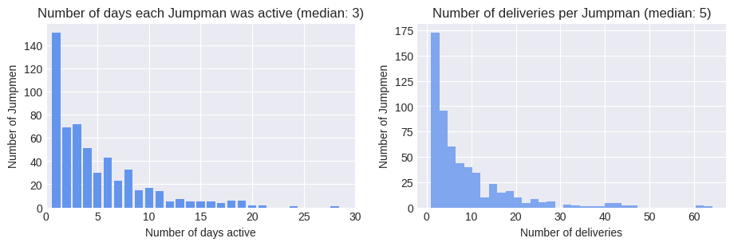

```python
# ---------- Analyze Jumpmen activity ---------- #
data_dt['day'] = data_dt.when_the_delivery_started.apply(lambda x: x.day)
data_jm = pd.crosstab(data_dt.jumpman_id, data_dt.day)
# Count number of deliveries for each jumpman:
n_deliveries_jm = list(data_jm.sum(axis=1))

# Count number of days that each jumpman was active:
n_days_jumpman = []
for jumpman_id in data_jm.index:
    n_days_jumpman.append(sum(data_jm.loc[jumpman_id, :] > 0))
data_jm['n_days_jumpman'] = n_days_jumpman
n_days_count = []
for n_days in range(1, 31):
    n_days_count.append(sum(data_jm.n_days_jumpman == n_days))

fig, [ax1, ax2] = plt.subplots(nrows=1, ncols=2, figsize=(11, 3))
plt.subplots_adjust(hspace=0.4)
plt.rcParams.update({'font.size': 10})

# Barplot of number of days each Jumpman was active:
ax1 = plt.subplot(121)
ax1.bar(list(np.arange(1,31)), n_days_count, color='cornflowerblue')
ax1.set_xlim([0, 30])
ax1.set_xlabel('Number of days active')
ax1.set_ylabel('Number of Jumpmen')
ax1.set_title('Number of days each Jumpman was active (median: %0.0f)' % np.median(n_days_jumpman))

# Histogram of number of deliveries per Jumpman:
ax2 = plt.subplot(122)
ax2.hist(n_deliveries_jm, bins=34, alpha=0.8, color='cornflowerblue')
ax2.set_xlabel('Number of deliveries')
ax2.set_ylabel('Number of Jumpmen')
ax2.set_title('Number of deliveries per Jumpman (median: %0.0f)' % (np.median(n_deliveries_jm)))
plt.show()
```

The plots above show that many of the 578 Jumpmen were only active on one day (many of them only executed one delivery). Many of the Jumpmen appear to only have "tried out" the service and are not yet committed to participate more frequently.

### 7. Customer retention

Let's take a look at customer retention. Let's define a returning customer as a customer that used Jumpman23 at least twice during the one month period. For this purpose we don't consider customers that ordered for the first time on any of the last seven days of the period since they might become returning customers within an additional few days.

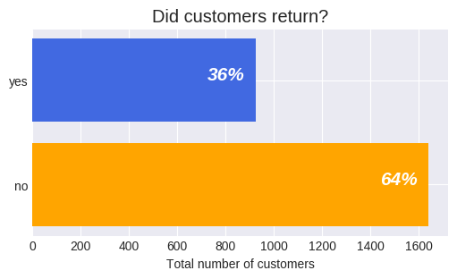

```python
# ---------- Analyze customer retention ---------- #
data_cr = data_ud[data_ud['when_the_delivery_started'].apply(lambda x: x.day) <= n_days - 7]
data_cr.groupby('customer_id').agg('count')
returning_costumers = pd.DataFrame(data_ud['customer_id'].value_counts() > 1)
return_customer = []
for id_ in data_cr['customer_id']:
    if returning_costumers.loc[id_].bool():
        return_customer.append(1)
    else:
        return_customer.append(0)
data_cr['return_customer'] = return_customer
# Remove rows with customers that already appeared before:
customer_ids_appeared = []
customer_first_time = []
for id_ in data_cr['customer_id']:
    if id_ in customer_ids_appeared:
        customer_first_time.append(False)
    else:
        customer_first_time.append(True)
        customer_ids_appeared.append(id_)
data_cr['customer_first_time'] = customer_first_time
data_cr = data_cr[data_cr['customer_first_time']]
# Annotate bars with percentage:
yes = int(np.round(100 * data_cr['return_customer'].sum() / data_cr['return_customer'].shape[0]))
no = 100 - yes
labels = [str(no) + '%', str(yes) + '%']
# Create plot:
fig, ax = plt.subplots()
plt.rcParams.update({'figure.figsize': [4.5, 2.5], 'font.size': 12})
ax.barh(['no', 'yes'], data_cr['return_customer'].value_counts(), color=['orange', 'royalblue'])
ax.set_xlabel('Total number of customers')
ax.set_title('Did customers return?')
rects = ax.patches
for rect, label in zip(rects, labels):
    x_value = rect.get_width()
    y_value = rect.get_y() + rect.get_height() / 2
    ax.text(x_value - 200, y_value, label, color='white', fontsize=15, style='italic', weight='bold')#,
plt.show()
```

We see that only 36% of customers returned after using Jumpman23 for the first time. This is certainly an area with potential for improvement. Let's see if we can find indicators of what factors lead to customer retention.

#### Fraction of returning customers varies by pickup area

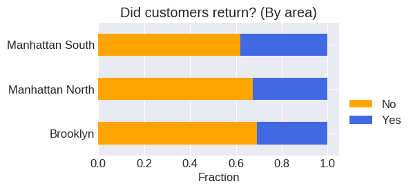

```python
# ---------- Customer retention by area ---------- #
ct_return_location = pd.crosstab(data_cr['pickup_area'], data_cr['return_customer'], normalize='index')
fig, ax = plt.subplots()
plt.rcParams.update({'figure.figsize': [5, 3], 'font.size': 12})
ax = ct_return_location.plot(kind='barh', stacked=True, ax=ax, color=['orange', 'royalblue'])
ax.set_ylabel('', fontsize=14)
ax.set_xlabel('Fraction')
ax.legend(['No', 'Yes'], bbox_to_anchor=(1, 0.5))
ax.set_title('Did customers return? (By area)')
plt.show()
```

While customers that ordered in Manhattan South are returning most often by a slight margin, the pickup are does not seem to be a strong indicator of customer retention.

#### Returning customers by delivery time

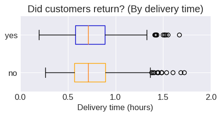

```python
# ---------- Customer retention by delivery speed ---------- #
fig, ax = plt.subplots(figsize=(5, 2))
bp = ax.boxplot([data_cr[data_cr.return_customer==0].dropna().time_delivery, \
             data_cr[data_cr.return_customer==1].dropna().time_delivery],
           widths=(0.5, 0.5), vert=False)
ax.set_yticklabels(['no', 'yes'])
ax.set_xlabel('Delivery time (hours)')
ax.set_xlim(0, 2)
ax.set_title('Did customers return? (By delivery time)')
for patch in bp['boxes']:
    patch.set(color = 'firebrick')
colors = ['orange', 'mediumblue']
for patch, color in zip(bp['boxes'], colors):
    patch.set(color=color)
plt.show()
```

Another idea is that the delivery time has an influence on customers loyalty. If deliveries take longer on average, it might upset the customer and he/she might not return. The median delivery time is very similar between returning and non-returning customers. Non-returning customers experienced unusually long waiting times slightly more often than returning ones.

#### Most frequent places categories and returning customers by places category

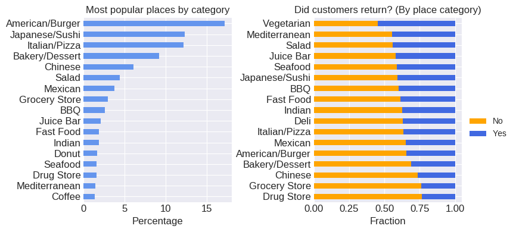

```python
# ---------- Analyze categories of most popular places ---------- #
data_pc = data_ud[data_ud.place_category != 'Unknown'] # <- don't consider 'Unknown' a category
data_cr_pc = data_cr[data_cr.place_category != 'Unknown']
total_n = data_pc.place_category.value_counts().sum()
top_15_place_cat = data_pc.place_category.value_counts()[:17]
top_15_place_cat = top_15_place_cat[::-1] / (total_n / 100)
top_15_categories = list(data_cr_pc.place_category.value_counts().iloc[:17].index)
data_cr_top15 = data_cr_pc[data_cr_pc.place_category.isin(top_15_categories)]
ct_return_cat = pd.crosstab(data_cr_top15.place_category, data_cr_top15.return_customer, \
                            normalize='index').sort_values(by=0, ascending=False)
# Create plots:
fig, [ax1, ax2] = plt.subplots(nrows=1, ncols=2, figsize=(8, 4), constrained_layout=True)
plt.subplots_adjust(wspace=10)
plt.rcParams.update({'font.size': 10})
# Plot of most popular places:
ax1 = top_15_place_cat.plot(kind='barh', ax=ax1, color='cornflowerblue')
ax1.set_title('Most popular places by category')
ax1.set_xlabel('Percentage')
fig.tight_layout()
# Plot most popular places by customer retention:
ax2 = ct_return_cat.plot(kind='barh', stacked=True, ax=ax2, color=['orange', 'royalblue'])
ax2.set_ylabel('', fontsize=14)
ax2.set_xlabel('Fraction')
ax2.legend(['No', 'Yes'], bbox_to_anchor=(1, 0.5))
ax2.set_title('Did customers return? (By place category)')
fig.show()
```

We can see the American, Japanese and Italian food is especially popular in New York. The customer retention shows little variance among these popular categories. Customers who ordered from a vegetarian place when they used the service for the first time are the only ones that returned in more than 50% of the cases. However, vegetarian places only represent a small fraction (~1.5%) of all orders.